# Homework2_SDS315

Caroline Zhuang

# **Question 1**

## **Part A**

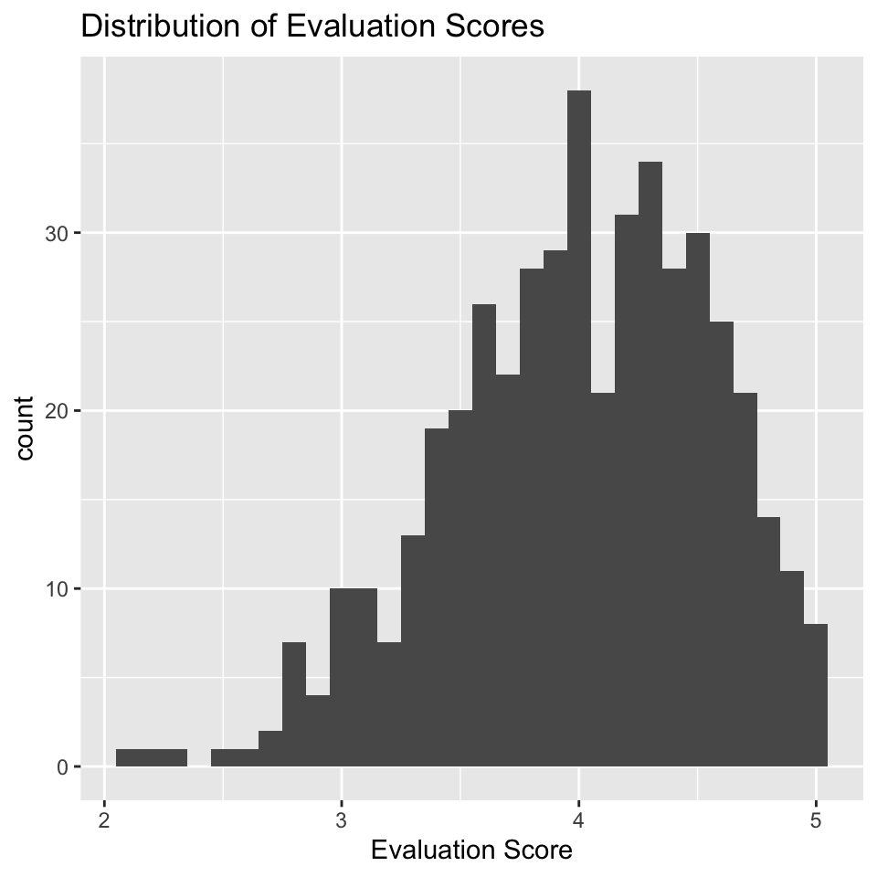

The histogram above shows the distribution of the UT professors’ evaluation scores. The median evaluation score is 4 and the mean score is 3.9982721. The scores are denser to the right.

## **Part B**

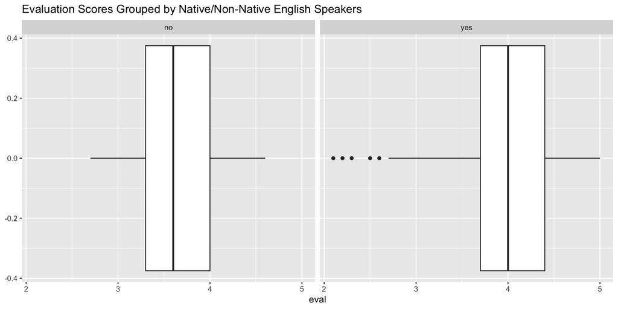

The side-by-side boxplots show the distribution of the professors’ evaluation scores, grouped by if the professor is a native English speaker or not. The median evaluation score of native speakers is 4 compared to non-native speakers, 3.6. Native English speaker professors have more outliers than non-native professors, represented by the dots.

## **Part C**

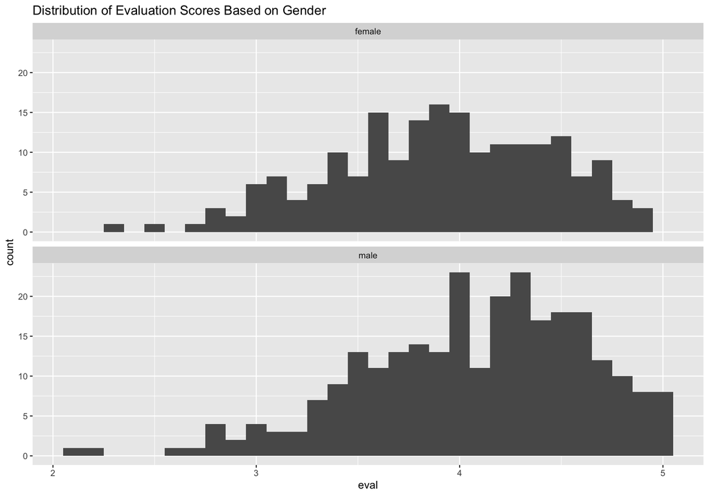

The histograms above show the distribution of evaluation scores, grouped by the gender of the professors. The median of female professors’ scores is 3.9 compared to the median of male professors 4.15. It is important to note that there are 268 male professors and 195 female professors.

## **Part D**

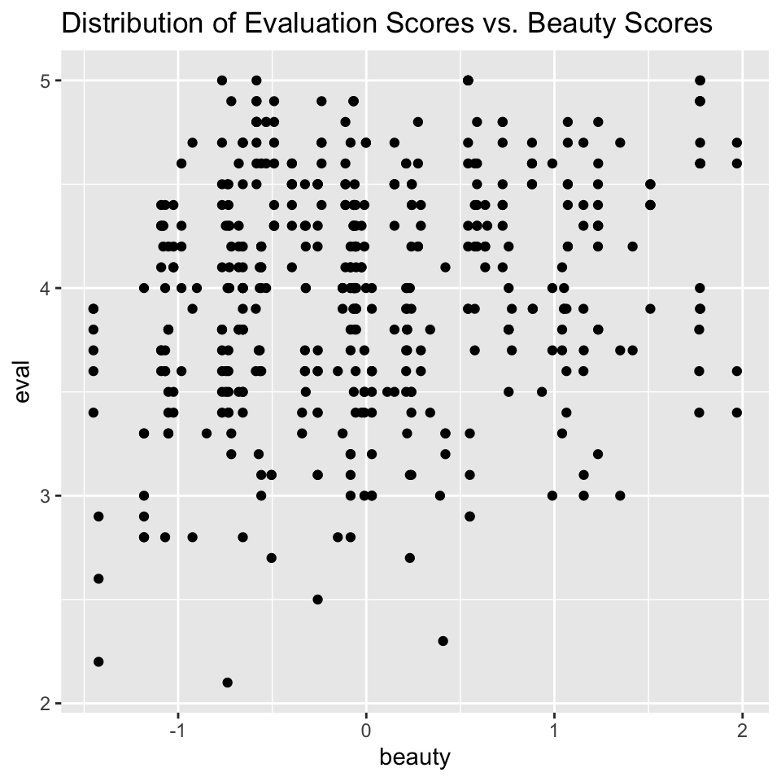

The scatter plot above shows the association between beauty score and evaluation score among the professors. From the graph, you can notice little correlation, since the points are spread out and random with no pattern. This is confirmed by the correlation statistic, which is 0.1890391, meaning a weak positive correlation.

# **Question 2**

## **Part A**

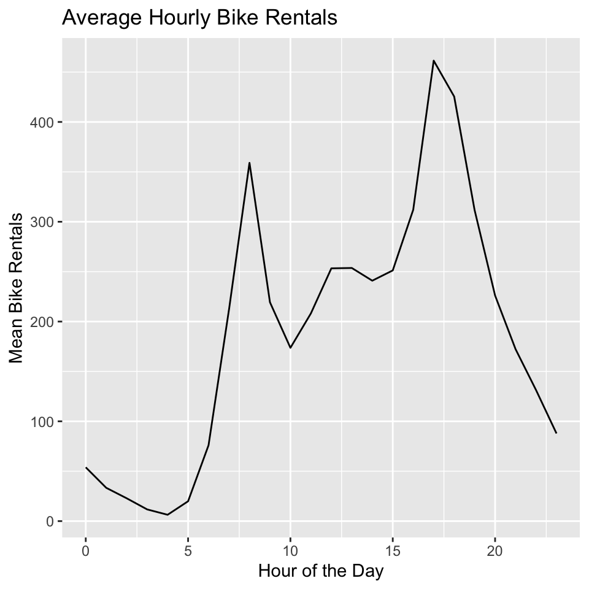

## **Part B**

[output not shown]

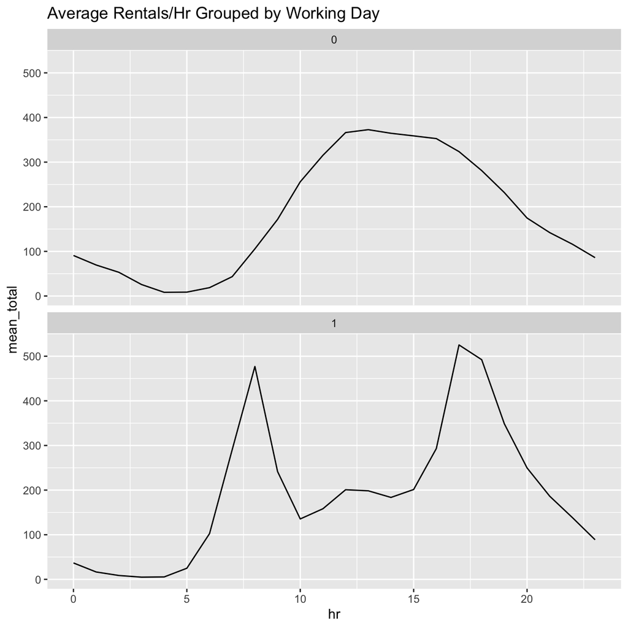

## **Part C**

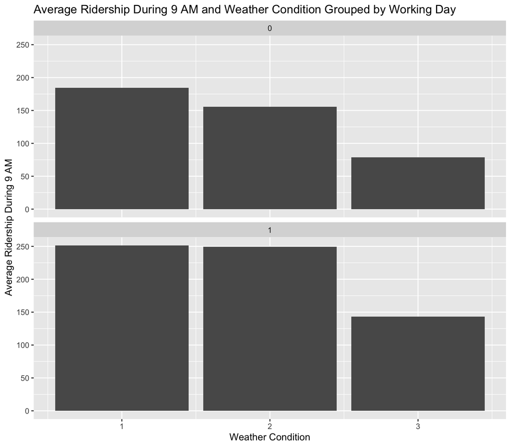

The bar graphs above show the average ridership during 9 AM for each weather condition, grouped by if it’s a working day or not. The numbers on the x-axis correspond with weather conditions. 1 equals clear, few clouds, partly cloudy, 2 equals mist, 3 equals light snow or light rain (notice: There is a weather condition 4 but it was never observed during hour 9). For working day, 0 corresponds to not a working day and 1 corresponds to a working day. Overall, the average rentals regardless of weather condition is higher for working days at hour 9 compared to non-working days at hour 9. From the bar graphs, the biggest difference between working day and non-working day is during weather condition 2, with working day having higher average rentals. For both working and non-working day, weather condition 3 has the lowest average rentals.

# **Question 3**

## **Part 1**

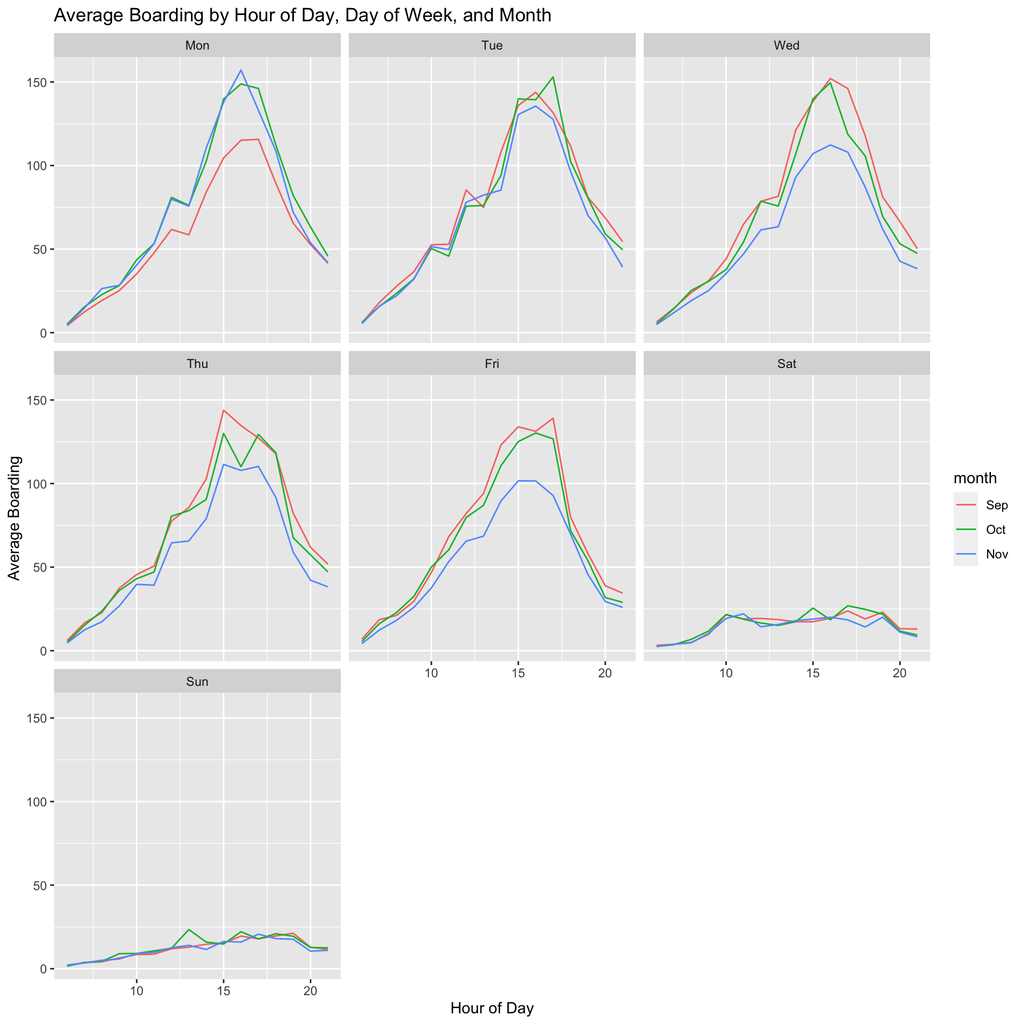

The line graph above shows the average boarding of the UT Capital Metro bus for the hours of the day, grouped by the day of week. The graph also shows differences and trends between the three months, November, October and September, represented by their respective colors. From the graph, the hour of peak boarding is broadly similar across the weekdays, at around hour 15 with around an average of 100-150. The weekends have significantly less boarding, probably due to weekdays being workdays. I think Mondays in September are significantly lower because of labor day weekend. There is no school for students and staff on labor day, which is a Monday, meaning less students will take the bus to travel to UT campus. I think boardings on Wednesday, Thursday and Friday are lower in November because of Thanksgiving break. In 2018, Thanksgiving break was from Wednesday-Friday, meaning students and staff are celebrating at home, so less students and staff will travel by bus to campus.

## **Part 2**

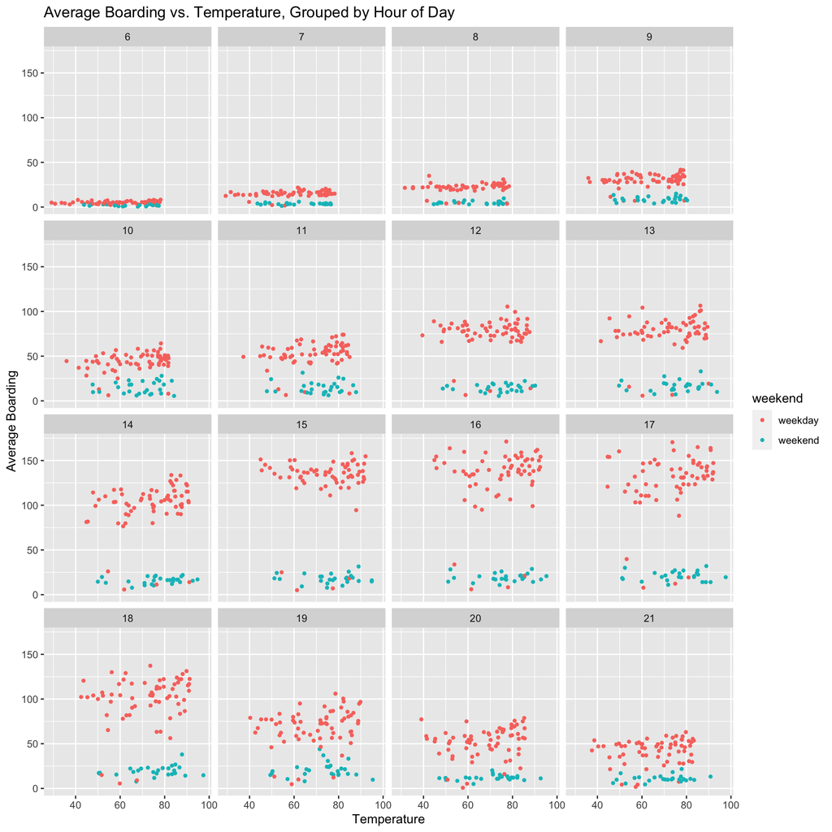

The figures above show the average boarding of the UT metro bus compared to the temperature of the day. The graphs are grouped by hour of the day (ex. 6 = 6 A.M). The red dots represent weekdays and the blue dots represent weekends. Overall, despite temperature and hour of the day, the weekends have lower averages than the weekdays. On weekdays, hours 14 through 18 have the highest average boarding. If we hold the hour of the day and weekend status constant, temperature doesn’t have a noticeable effect on average boarding. From the graphs, the points seem to be in somewhat of a straight line, meaning temperature doesn’t affect average boarding. This is probably because no matter the temperature, students and staff need to get to campus to attend class.

# **Question 4**

## **Part A**

```
## # A tibble: 10 × 3
## # Groups:   performer [10]
##    performer                                 song                          count
##    <chr>                                     <chr>                         <int>
##  1 Imagine Dragons                           Radioactive                      87
##  2 AWOLNATION                                Sail                             79
##  3 Jason Mraz                                I'm Yours                        76
##  4 The Weeknd                                Blinding Lights                  76
##  5 LeAnn Rimes                               How Do I Live                    69
##  6 LMFAO Featuring Lauren Bennett & GoonRock Party Rock Anthem                68
##  7 OneRepublic                               Counting Stars                   68
##  8 Adele                                     Rolling In The Deep              65
##  9 Jewel                                     Foolish Games/You Were Meant…    65
## 10 Carrie Underwood                          Before He Cheats                 64
```

The table above shows the top ten longest charting songs on the Billboard 100 from 1958 to 2021. The table shows the performer, song, and count, which is equal to the total number of weeks charted.

## **Part B**

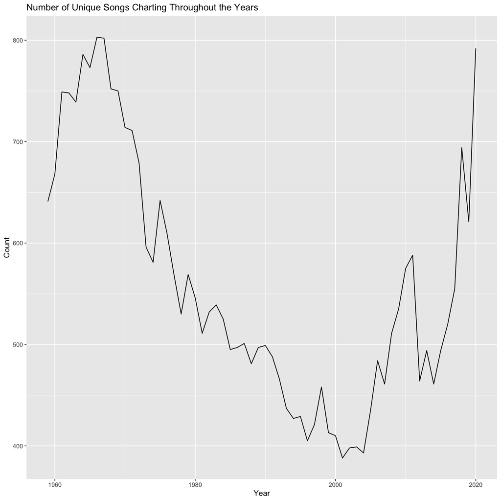

## **Part C**

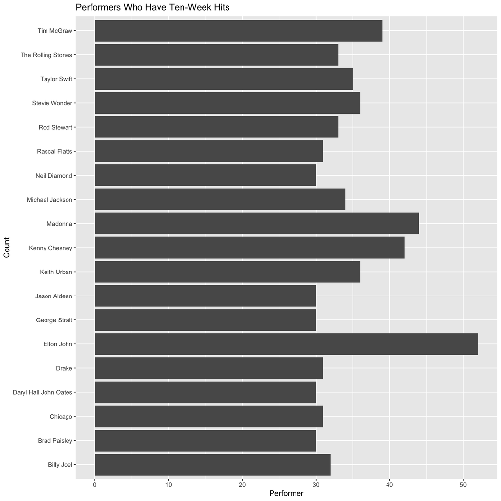

The bar graph above shows artists who have at least 30 unique songs that were “ten-week” hits and how many “ten-week” hits they have. A “ten-week” hit is a song that charts the Billboard 100 for at least 10 weeks. Based on this graph, Elton John has the most “ten-week” hits with a total of 52. There are a total of 19 artists that have had at least 30 unique songs as “ten-week” hits.